# Praca domowa 1

Mateusz Grzyb

## Zbiór danych

Nazwa: eucalyptus

Źródło: https://www.openml.org/d/188

## Opis zbioru

The objective was to determine which seedlots in a species are best for soil conservation in seasonally dry hill country. Determination is found by measurement of height, diameter by height, survival, and other contributing factors.

Abbrev - site abbreviation - enumerated

Rep - site rep - integer

Locality - site locality in the North Island - enumerated

Map_Ref - map location in the North Island - enumerated

Latitude - latitude approximation - enumerated

Altitude - altitude approximation - integer

Rainfall - rainfall (mm pa) - integer

Frosts - frosts (deg. c) - integer

Year - year of planting - integer

Sp - species code - enumerated

PMCno - seedlot number - integer

DBH - best diameter base height (cm) - real

Ht - height (m) - real

Surv - survival - integer

Vig - vigour - real

Ins_res - insect resistance - real

Stem_Fm - stem form - real

Crown_Fm - crown form - real

Brnch_Fm - branch form - real

Utility - utility rating - enumerated

## Wczytanie pakietów

```r
library(knitr)
library(kableExtra)

library(dplyr)
library(purrr)
library(reshape2)

library(ggplot2)
library(cowplot)
library(visdat)
library(naniar)

library(mlr3)
library(mlr3learners)
library(mlr3pipelines)
library(mlr3measures)
library(mlr3viz)
```

## Wczytanie danych

```r
# braki danych oznaczono za pomoca '?'
data <- read.csv('./dataset_194_eucalyptus.csv', stringsAsFactors=FALSE, na.strings='?')

kable(head(data)) %>%
  kable_styling(bootstrap_options='striped') %>%
  scroll_box(width="100%", height="200px")
```

| Abbrev | Rep | Locality | Map_Ref | Latitude | Altitude | Rainfall | Frosts | Year | Sp | PMCno | DBH | Ht | Surv | Vig | Ins_res | Stem_Fm | Crown_Fm | Brnch_Fm | Utility |
| --- | --- | --- | --- | --- | --- | --- | --- | --- | --- | --- | --- | --- | --- | --- | --- | --- | --- | --- | --- |
| Cra | 1 | Central_Hawkes_Bay | N135_382/137 | 39__38 | 100 | 850 | -2 | 1980 | co | 1520 | 18.45 | 9.96 | 40 | 4.0 | 3.0 | 3.5 | 4.0 | 3.5 | good |
| Cra | 1 | Central_Hawkes_Bay | N135_382/137 | 39__38 | 100 | 850 | -2 | 1980 | fr | 1487 | 13.15 | 9.65 | 90 | 4.5 | 4.0 | 3.5 | 3.5 | 3.0 | best |
| Cra | 1 | Central_Hawkes_Bay | N135_382/137 | 39__38 | 100 | 850 | -2 | 1980 | ma | 1362 | 10.32 | 6.50 | 50 | 2.3 | 2.5 | 3.0 | 3.5 | 3.0 | low |
| Cra | 1 | Central_Hawkes_Bay | N135_382/137 | 39__38 | 100 | 850 | -2 | 1980 | nd | 1596 | 14.80 | 9.48 | 70 | 3.7 | 3.0 | 3.3 | 4.0 | 3.5 | good |
| Cra | 1 | Central_Hawkes_Bay | N135_382/137 | 39__38 | 100 | 850 | -2 | 1980 | ni | 2088 | 14.50 | 10.78 | 90 | 4.0 | 2.7 | 3.3 | 3.0 | 3.0 | good |
| Cra | 1 | Central_Hawkes_Bay | N135_382/137 | 39__38 | 100 | 850 | -2 | 1980 | ob | 1522 | 17.01 | 12.28 | 70 | 5.0 | 4.0 | 5.0 | 4.0 | 4.5 | best |

## Czyszczenie danych

```r
data <- data %>%
  # w kolumnie Latitude zmienie minuty na setne stopnia, dzieki czemu uzyskam wlasciwa zmienna numeryczna
  mutate(Latitude=-as.numeric(substr(Latitude, 1, 2))-as.numeric(substr(Latitude, 5, 6))/60) %>%
  # szesc obserwacji zmiennej Latitude jest nierealnych (klimat arktyczny), wiec zmienie je na NA
  mutate(Latitude=ifelse(Latitude<(-60), NA, Latitude)) %>%
  # jedna obserwacja zmiennej DBH jest nierealna (80 razy wieksza od drugiej najwiekszej), wiec zmienie ja na NA
  mutate(DBH=ifelse(DBH>100, NA, DBH))
```

## Typy zmiennych i braki danych

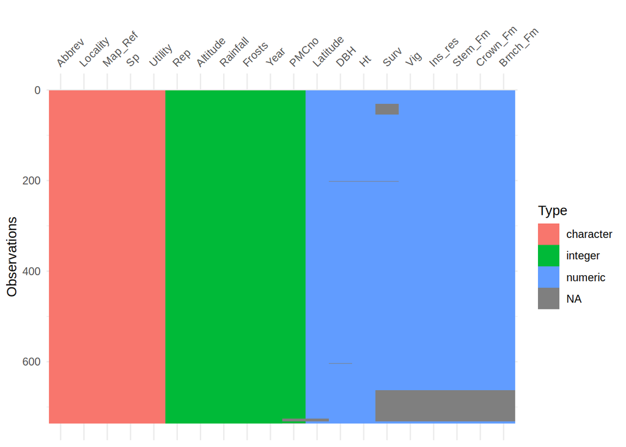

```r
vis_dat(data)
```

```r
kable(filter(miss_var_summary(data), n_miss>0)) %>%
  kable_styling(bootstrap_options='striped')
```

| variable | n_miss | pct_miss |
| --- | --- | --- |
| Surv | 94 | 12.7717391 |
| Vig | 69 | 9.3750000 |
| Ins_res | 69 | 9.3750000 |
| Stem_Fm | 69 | 9.3750000 |
| Crown_Fm | 69 | 9.3750000 |
| Brnch_Fm | 69 | 9.3750000 |
| PMCno | 7 | 0.9510870 |
| Latitude | 6 | 0.8152174 |
| DBH | 2 | 0.2717391 |
| Ht | 1 | 0.1358696 |

#### Komentarz

W danych występują atrybuty typu ‘character’, ‘integer’ i ‘numeric’. Są to zarówno zmienne kategoryczne jak i numeryczne. Występują braki danych, najwięcej w kolumnach ‘Surv’, ‘Vig’, ‘Ins_res’, ‘Stem_Fm’, ‘Crown_Fm’ i "Brnch_Fm’.

## Analiza zmiennych

### Rozkłady zmiennych kategorycznych

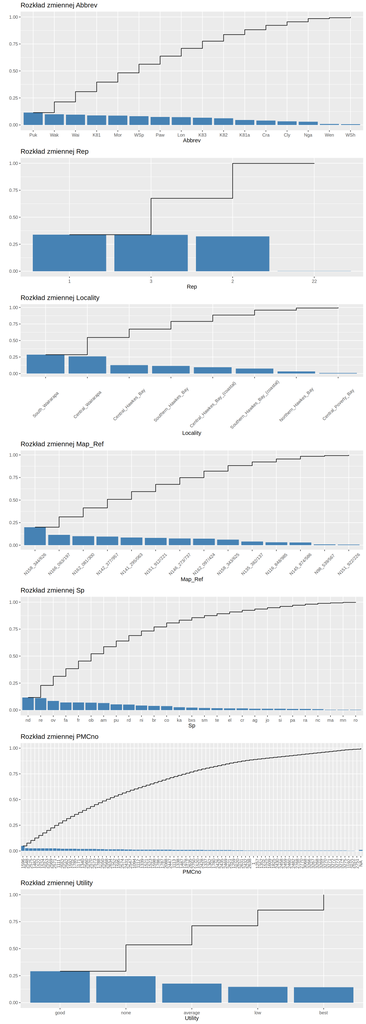

```r
variables <- c('Abbrev', 'Rep', 'Locality', 'Map_Ref', 'Sp', 'PMCno', 'Utility')
variables <- set_names(variables)
angles <- c(0, 0, 45, 45, 0, 90, 0)

pareto_fun <- function(data, variable, label_angle) {
  data[[variable]] <- factor(data[[variable]], levels=names(sort(table(data[[variable]]), decreasing=T)))
  ggplot(data, aes_string(x=variable)) +
    geom_bar(aes(y=(..count..)/sum(..count..)), fill='steelblue') +
    stat_count(aes(y=cumsum(..count..)/sum(..count..)), geom="step", group=1) +
    theme(axis.text.x=element_text(angle=label_angle, hjust=0.5, vjust=0.5)) +
    labs(title=paste('Rozkład zmiennej', variable)) +
    ylab(label='') +
    xlab(label=variable)
}

plots <- map2(variables, angles, ~pareto_fun(data, .x, .y))
plot_grid(plotlist=plots, ncol=1, nrow=length(variables))
```

#### Komentarz

- niemal 50% drzew pochodzi z 5 (na 16) stanowisk,
- ponad 50% drzech pochodzi z rejonu Wairarapa,

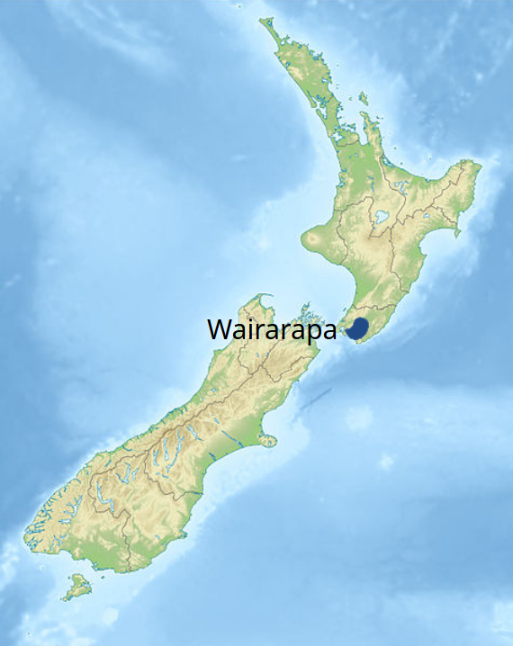

- ponad 50% drzew jest jednego z 6 (na 27) gatunków,
- nasiona drzew pochodziły z 85 różnych partii,
- najwięcej jest drzew o użyteczności “good”, ale drugie najpowszechniejsze są o użyteczności “none”, a ostatnie “best”

### Rozkłady zmiennych numerycznych

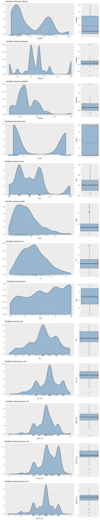

```r
variables <- setdiff(colnames(data), variables)
variables <- set_names(variables)

dist_fun <- function(data, variable) {
  p1<- ggplot(data, aes_string(x=variable)) +
    geom_density(fill='steelblue', alpha=.5) +
    geom_rug(aes(y=0), position=position_jitter(height=0, width=0.1), colour='steelblue', alpha=.25, sides='b') +
    labs(title=paste('Rozkład zmiennej', variable)) +
    ylab(label='') +
    xlab(label=variable)
  p2 <- ggplot(data, aes_string(y=variable)) +
    geom_boxplot(fill='steelblue', alpha=.5) +
    stat_summary(fun.y=mean, geom ="errorbar", aes(x=0, ymax=..y..,ymin=..y..), width=.75, linetype = "dashed") +
    labs(title=(' ')) +
    xlab(label=' ') +
    ylab(label=variable) +
    theme(
      axis.text.x=element_blank(),
      axis.ticks.x=element_blank()
    )
  plot_grid(p1, p2, ncol=2, nrow=1, rel_widths=c(0.75, 0.25))
}

plots <- map(variables, ~dist_fun(data, .x))
plot_grid(plotlist=plots, ncol=1, nrow=length(variables))
```

#### Komentarz

- Rozkład szerokości geograficznej jest dwumodalny, minimalna wartość to -41.27°, a maksymalna -39°,
- 50% drzew zajduje się na wysokości 150-180 m n.p.m., minimalna wartość to 70 m n.p.m., a maksymalna 300 m n.p.m,
- średnie opady wynoszą 1095 mm rocznie, minimalna wartość to 850 mm rocznie, a maksymalna 1750 mm rocznie,
- zmienna Frosts przyjmuje tylko dwie wartości - -2 °C i -3 °C, przy czym wartość -3 °C występuje częściej,
- badane drzewa sadzone były w latach 1980-1986, najwięcej z nich zasadzono w 1981 i 1983 roku,
- zmienna DBH ma rozkład jednomodalny o dodatniej asymetrii, średnia jej wartość wynosi 15.71 cm,
- wysokość drzew ma rozkład jednomodalny o dodatniej asymetrii, średnia jej wartość to 9.3 m, a najwyższe drzewo miało wysokość 21.79 m,
- średnia przeżywalność wynosi 60 (wartości są z przedziału 1.5-100), a najczęstszą wartością wigoru jest 3 (wartości są z przedziału 0.5-5),
- rozkłady zmiennych Ins_res, Stem_Fm, Crown_Fm i Brnch_Fm są widocznie podobne (w szczególności Stem_Fm i Brnch_Fm)

## Korelacje zmiennych

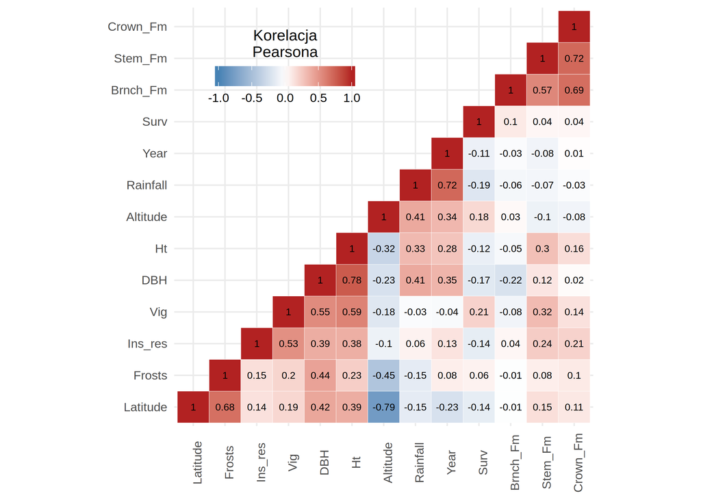

```r
cormat <- round(cor(data[variables], use="na.or.complete"), 2)
dd <- as.dist((1-cormat)/2)
hc <- hclust(dd)
cormat <- cormat[hc$order, hc$order]
cormat[lower.tri(cormat)] <- NA
melted_cormat <- melt(cormat, na.rm=T)

ggplot(data=melted_cormat, aes(Var2, Var1, fill=value)) +
  geom_tile(color="white") +
  scale_fill_gradient2(low="steelblue", high="firebrick", mid="white", midpoint=0,
                       limit=c(-1,1), space="Lab", name="Korelacja\nPearsona") +
  geom_text(aes(Var2, Var1, label = value), color = "black", size = 2.5) +
  theme_minimal() +
  theme(
    axis.text.x=element_text(angle=90),
    axis.title.x=element_blank(),
    axis.title.y=element_blank(),
    axis.ticks = element_blank(),
    legend.justification = c(1, 0),
    legend.position = c(0.45, 0.75),
    legend.direction = "horizontal") +
  guides(fill = guide_colorbar(barwidth = 7, barheight = 1, title.position = "top", title.hjust = 0.5)) +
  coord_fixed()
```

#### Komentarz

Wysoce skorelowane są:

- szerokość geograficzna i wysokość nad poziomem morza / przymrozki,
- odporność na insekty i wigor,
- wigor i DBH / wysokość drzewa,
- DBH i wysokość drzewa,
- roczne opady i rok zasadzenia,
- Brnch_Fm i Stem_Fm / Crown_Fm,
- Stem_Fm i Crown_Fm

## Zależności zmiennych kategorycznych

Wartości niektórych zmiennych kategorycznych jednozacznie wyznaczają wartości innych w danym wierszu.

Funkcja sprawdzająca:

```r
test <- function(data, variable1, variable2, na.rm=F) {
  values <- unique(data[[variable1]])
  values <- values[!is.na(values)]
  responses <- rep(F, length(values))
  if(na.rm) {
    responses <- as.logical(map(values,
                                ~length(na.omit(unique(data[data[variable1]==.x, variable2]))))%in%c(0, 1))
  }
  else {
    responses <- as.logical(map(values,
                                ~(length(unique(data[data[variable1]==.x, variable2])))==1 &
                                  length(na.omit(unique(data[data[variable1]==.x, variable2])))==1))
  }
  all(responses)
}
```

Krótki test poprawawnego działania funkcji:

```r
# powinno wyjsc TRUE
cat(paste('Czy zmienna Abbrev jednozacznie wyznacza zmienna Abbrev:', test(data, 'Abbrev', 'Abbrev')))
```

```
## Czy zmienna Abbrev jednozacznie wyznacza zmienna Abbrev: TRUE
```

```r
# powinno wyjsc FALSE
cat(paste('Czy zmienna Sp jednozacznie wyznacza zmienna Ht:', test(data, 'Sp', 'Ht')))
```

```
## Czy zmienna Sp jednozacznie wyznacza zmienna Ht: FALSE
```

Przykładowe tego typu związki:

```r
cat(paste0('Czy zmienna Abbrev jednozacznie wyznacza zmienna Locality: ',
           test(data, 'Abbrev', 'Locality'), '\n',
           'Czy zmienna Abbrev jednozacznie wyznacza zmienna Map_Ref: ',
           test(data, 'Abbrev', 'Map_Ref'), '\n',
           'Czy zmienna Abbrev jednozacznie wyznacza zmienna Latitude: ',
           test(data, 'Abbrev', 'Latitude', T), '\n',
           'Czy zmienna Latitude jednozacznie wyznacza zmienna Rainfall: ',
           test(data, 'Latitude', 'Rainfall', T), '\n',
           'Czy zmienna Latitude jednozacznie wyznacza zmienna Altitude: ',
           test(data, 'Latitude', 'Altitude')))
```

```
## Czy zmienna Abbrev jednozacznie wyznacza zmienna Locality: TRUE
## Czy zmienna Abbrev jednozacznie wyznacza zmienna Map_Ref: TRUE
## Czy zmienna Abbrev jednozacznie wyznacza zmienna Latitude: TRUE
## Czy zmienna Latitude jednozacznie wyznacza zmienna Rainfall: TRUE
## Czy zmienna Latitude jednozacznie wyznacza zmienna Altitude: FALSE
```

#### Komentarz

Wartość zmiennej Abbrev jednoznacznie wyznacza wartości zmiennych Locality, Map_Ref i Latitude (o ile ta ostatnia jest znana). Podobnie szerokość geograficzna jednoznacznie wyznacza roczne opady deszczu (o ile są znane), ale już nie wysokość nad poziomem morza.

## Przygotowanie danych do ML

Po pierwsze, w obecnej formie zbiór danych stanowi zadanie klasyfikacji wieloklasowej. Zmienna docelowa - Utility, przyjmuje 5 wartości - “none”, “low”, “average”, “good” i “best”. W związku z tym, że na zajęciach nie poruszaliśmy jeszcze tego tematu, powyższy problem zamienię na klasyfikację binarną, w sposób następujący - drzewa o użyteczności “none”, “low” i “average” umieszczę w grupie 0, a drzewa o użyteczności “good” i “best” w grupie 1. Tym sposobem, zadaniem algorytmu będzie rozpoznawanie drzew o ponadprzeciętnej użyteczności.

```r
data <- mutate(data, Utility=as.factor(ifelse(Utility %in% c('good', 'best'), 1, 0)))

kable(head(select(data, Utility))) %>%
  kable_styling(bootstrap_options='striped') %>%
  scroll_box(width="100%", height="200px")
```

| Utility |
| --- |
| 1 |
| 1 |
| 0 |
| 1 |
| 1 |
| 1 |

Po drugie, z logicznego punktu widzenia atrybuty takie jak Abbrev, Rep, Locality, czy Map_Ref nie powinny mieć wpływu na użyteczność poszczególnych drzew (np. Abbrev), bądź też są z nią tylko pośrednio związane, a inna zmienna lepiej opisuje ten związek (np. Locality i Latitude). Pozbędę się tych zmiennych.

```r
data <- select(data, -Abbrev, -Rep, -Locality, -Map_Ref)

kable(head(data)) %>%
  kable_styling(bootstrap_options='striped') %>%
  scroll_box(width="100%", height="200px")
```

| Latitude | Altitude | Rainfall | Frosts | Year | Sp | PMCno | DBH | Ht | Surv | Vig | Ins_res | Stem_Fm | Crown_Fm | Brnch_Fm | Utility |
| --- | --- | --- | --- | --- | --- | --- | --- | --- | --- | --- | --- | --- | --- | --- | --- |
| -39.63333 | 100 | 850 | -2 | 1980 | co | 1520 | 18.45 | 9.96 | 40 | 4.0 | 3.0 | 3.5 | 4.0 | 3.5 | 1 |
| -39.63333 | 100 | 850 | -2 | 1980 | fr | 1487 | 13.15 | 9.65 | 90 | 4.5 | 4.0 | 3.5 | 3.5 | 3.0 | 1 |
| -39.63333 | 100 | 850 | -2 | 1980 | ma | 1362 | 10.32 | 6.50 | 50 | 2.3 | 2.5 | 3.0 | 3.5 | 3.0 | 0 |
| -39.63333 | 100 | 850 | -2 | 1980 | nd | 1596 | 14.80 | 9.48 | 70 | 3.7 | 3.0 | 3.3 | 4.0 | 3.5 | 1 |
| -39.63333 | 100 | 850 | -2 | 1980 | ni | 2088 | 14.50 | 10.78 | 90 | 4.0 | 2.7 | 3.3 | 3.0 | 3.0 | 1 |
| -39.63333 | 100 | 850 | -2 | 1980 | ob | 1522 | 17.01 | 12.28 | 70 | 5.0 | 4.0 | 5.0 | 4.0 | 4.5 | 1 |

Po trzecie, zmienię typ atrybutu Sp z “character” na “factor” (nieuporządkowany).

```r
data <- mutate(data, Sp=factor(Sp, levels=unique(Sp), ordered=F))
```

Ostatecznie, podzielę dane na zbiór treningowy i testowy.

```r
set.seed(0)
train_set <- sample(nrow(data), 0.8*nrow(data))
test_set <- setdiff(seq_len(nrow(data)), train_set)
```

## Imputacja i ML

Użyję algorytmu “Penalized Logistic Regression” z pakietu “glmnet”.

Posłużę się procesem, który był omawiany na ostatnich zajęciach:

1. Stosujemy imputację na całym zbiorze treningowym,
2. dzielimy uzupełniony zbiór treningowy na podzbiory i przeprowadzamy kroswalidację,
3. stosujemy imputację na zbiorze testowym,
4. oceniamy algorytm na zbiorze testowym.

### Usunięcie wierszy z brakami danych

```r
# usuniecie wierszy z brakami danych
data_no_na <- na.omit(data)
train_set_no_na <- intersect(seq_len(nrow(data))[complete.cases(data)], train_set)
test_set_no_na <- intersect(seq_len(nrow(data))[complete.cases(data)], test_set)

# przygotowanie obiektow
resampling <- rsmp("cv", folds = 5)
encoder <- po('encode', method='one-hot', affect_columns=selector_type('factor'))
learner <- lrn('classif.glmnet', predict_type = 'prob')
glearner <- GraphLearner$new(encoder %>>% learner)

# kroswalidacja na zbiorze treningowym
task_1 <- TaskClassif$new(id='eucalyptus', backend=data[train_set_no_na, ], target='Utility', positive='1')
rr <- resample(task_1, glearner, resampling, store_models = TRUE)
```

```
## INFO  [17:47:14.246] Applying learner 'encode.classif.glmnet' on task 'eucalyptus' (iter 1/5)
## INFO  [17:47:15.314] Applying learner 'encode.classif.glmnet' on task 'eucalyptus' (iter 2/5)
## INFO  [17:47:15.726] Applying learner 'encode.classif.glmnet' on task 'eucalyptus' (iter 3/5)
## INFO  [17:47:16.090] Applying learner 'encode.classif.glmnet' on task 'eucalyptus' (iter 4/5)
## INFO  [17:47:16.461] Applying learner 'encode.classif.glmnet' on task 'eucalyptus' (iter 5/5)
```

```r
rr$score(msr('classif.acc'))[, c('iteration', 'classif.acc')]
```

```
##    iteration classif.acc
## 1:         1   0.9117647
## 2:         2   0.9313725
## 3:         3   0.9019608
## 4:         4   0.8529412
## 5:         5   0.8316832
```

```r
rr$score(msr('classif.ce'))[, c('iteration', 'classif.ce')]
```

```
##    iteration classif.ce
## 1:         1 0.08823529
## 2:         2 0.06862745
## 3:         3 0.09803922
## 4:         4 0.14705882
## 5:         5 0.16831683
```

```r
rr$score(msr('classif.precision'))[, c('iteration', 'classif.precision')]
```

```
##    iteration classif.precision
## 1:         1         0.8837209
## 2:         2         0.9411765
## 3:         3         0.9361702
## 4:         4         0.7547170
## 5:         5         0.7924528
```

```r
rr$score(msr('classif.recall'))[, c('iteration', 'classif.recall')]
```

```
##    iteration classif.recall
## 1:         1      0.9047619
## 2:         2      0.9230769
## 3:         3      0.8627451
## 4:         4      0.9523810
## 5:         5      0.8750000
```

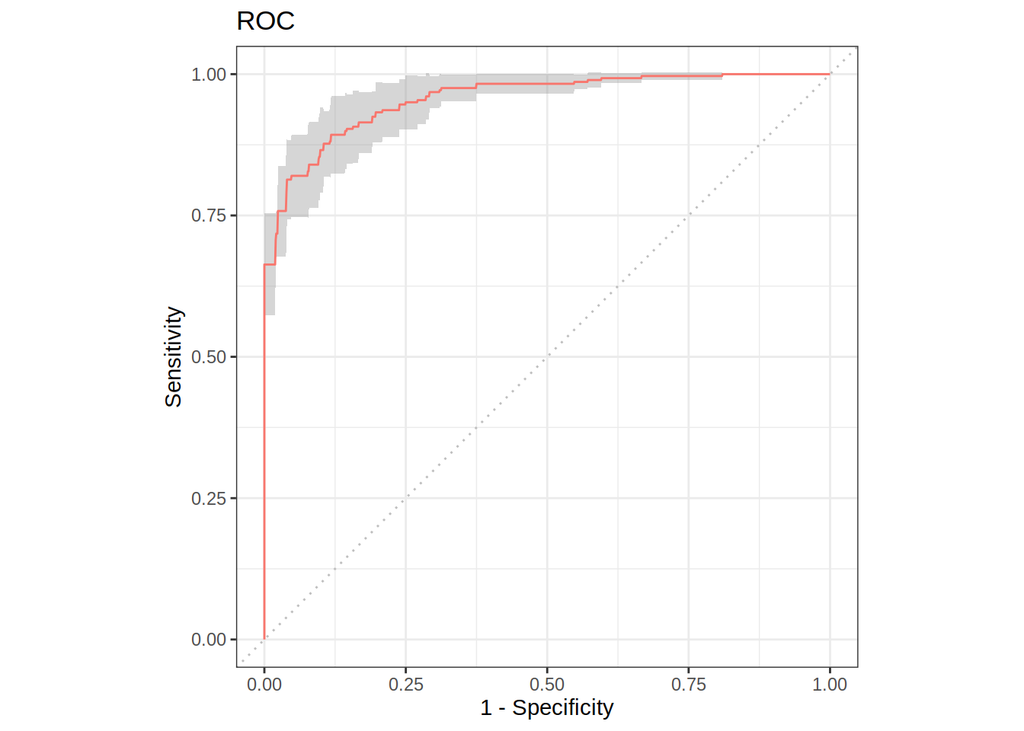

```r
autoplot(rr, type='roc')
```

```r
# uczenie na calym zbiorze treningowym
task_2 <- TaskClassif$new(id='eucalyptus', backend=data, target='Utility', positive='1')
glearner$train(task_2, row_ids=train_set_no_na)

# ocena na zbiorze testowym
prediction <- glearner$predict(task_2, row_ids=test_set_no_na)

prediction$score(msr('classif.acc'))
```

```
## classif.acc
##   0.9007634
```

```r
prediction$score(msr('classif.ce'))
```

```
## classif.ce
## 0.09923664
```

```r
prediction$score(msr('classif.precision'))
```

```
## classif.precision
##           0.90625
```

```r
prediction$score(msr('classif.recall'))
```

```
## classif.recall
##      0.8923077
```

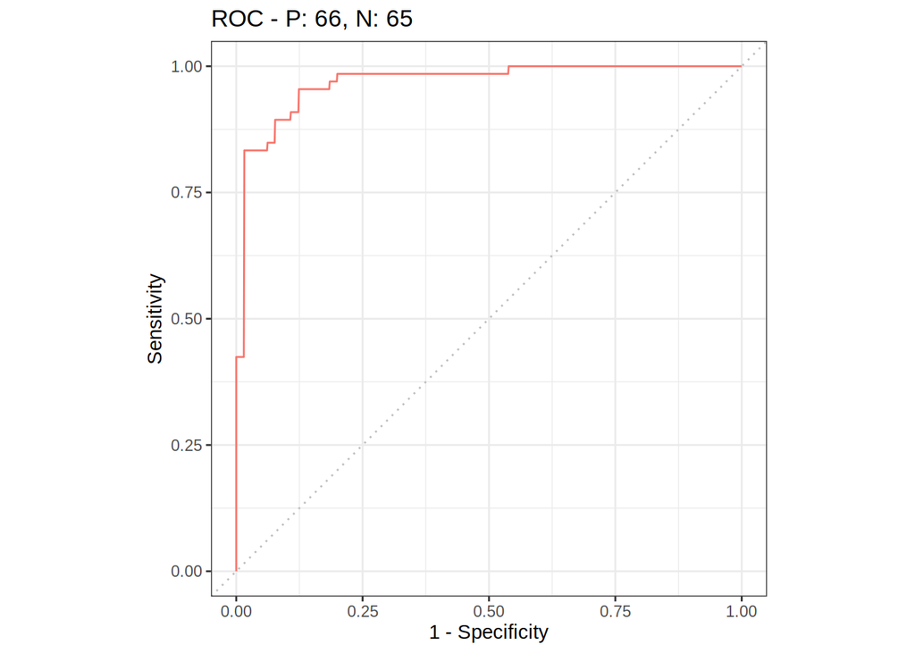

```r
autoplot(prediction, type='roc')
```

```r
prediction$score(msr('classif.auc'))
```

```
## classif.auc
##   0.9680653
```

### Usunięcie kolumn z brakami danych

```r
# usuniecie kolumn z brakami danych
variables <- unlist(lapply(data, function(x) any(is.na(x))))
variables <- names(variables)[!variables]
new_data <- data[, variables]

# przygotowanie obiektow
resampling <- rsmp("cv", folds = 5)
encoder <- po('encode', method='one-hot', affect_columns=selector_type('factor'))
learner <- lrn('classif.glmnet', predict_type = 'prob')
glearner <- GraphLearner$new(encoder %>>% learner)

# kroswalidacja na zbiorze treningowym
task_1 <- TaskClassif$new(id='eucalyptus', backend=new_data[train_set, ], target='Utility', positive='1')
rr <- resample(task_1, glearner, resampling, store_models = TRUE)
```

```
## INFO  [17:47:18.355] Applying learner 'encode.classif.glmnet' on task 'eucalyptus' (iter 1/5)
## INFO  [17:47:18.704] Applying learner 'encode.classif.glmnet' on task 'eucalyptus' (iter 2/5)
## INFO  [17:47:19.092] Applying learner 'encode.classif.glmnet' on task 'eucalyptus' (iter 3/5)
## INFO  [17:47:19.484] Applying learner 'encode.classif.glmnet' on task 'eucalyptus' (iter 4/5)
## INFO  [17:47:19.842] Applying learner 'encode.classif.glmnet' on task 'eucalyptus' (iter 5/5)
```

```r
rr$score(msr('classif.acc'))[, c('iteration', 'classif.acc')]
```

```
##    iteration classif.acc
## 1:         1   0.7033898
## 2:         2   0.7881356
## 3:         3   0.6779661
## 4:         4   0.7435897
## 5:         5   0.7435897
```

```r
rr$score(msr('classif.ce'))[, c('iteration', 'classif.ce')]
```

```
##    iteration classif.ce
## 1:         1  0.2966102
## 2:         2  0.2118644
## 3:         3  0.3220339
## 4:         4  0.2564103
## 5:         5  0.2564103
```

```r
rr$score(msr('classif.precision'))[, c('iteration', 'classif.precision')]
```

```
##    iteration classif.precision
## 1:         1         0.6170213
## 2:         2         0.6610169
## 3:         3         0.6909091
## 4:         4         0.6666667
## 5:         5         0.7826087
```

```r
rr$score(msr('classif.recall'))[, c('iteration', 'classif.recall')]
```

```
##    iteration classif.recall
## 1:         1      0.6304348
## 2:         2      0.8863636
## 3:         3      0.6440678
## 4:         4      0.7234043
## 5:         5      0.6428571
```

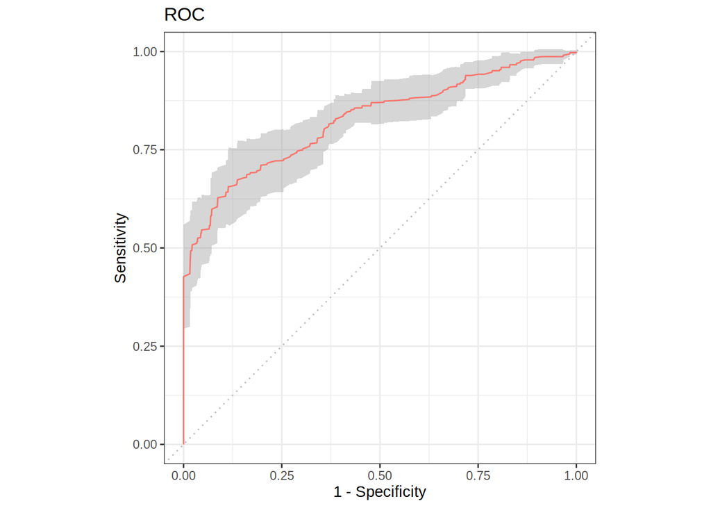

```r
autoplot(rr, type='roc')
```

```r
# uczenie na calym zbiorze treningowym
task_2 <- TaskClassif$new(id='eucalyptus', backend=new_data, target='Utility', positive='1')
glearner$train(task_2, row_ids=train_set_no_na)

# ocena na zbiorze testowym
prediction <- glearner$predict(task_2, row_ids=test_set)

prediction$score(msr('classif.acc'))
```

```
## classif.acc
##   0.6418919
```

```r
prediction$score(msr('classif.ce'))
```

```
## classif.ce
##  0.3581081
```

```r
prediction$score(msr('classif.precision'))
```

```
## classif.precision
##         0.5833333
```

```r
prediction$score(msr('classif.recall'))
```

```
## classif.recall
##      0.7313433
```

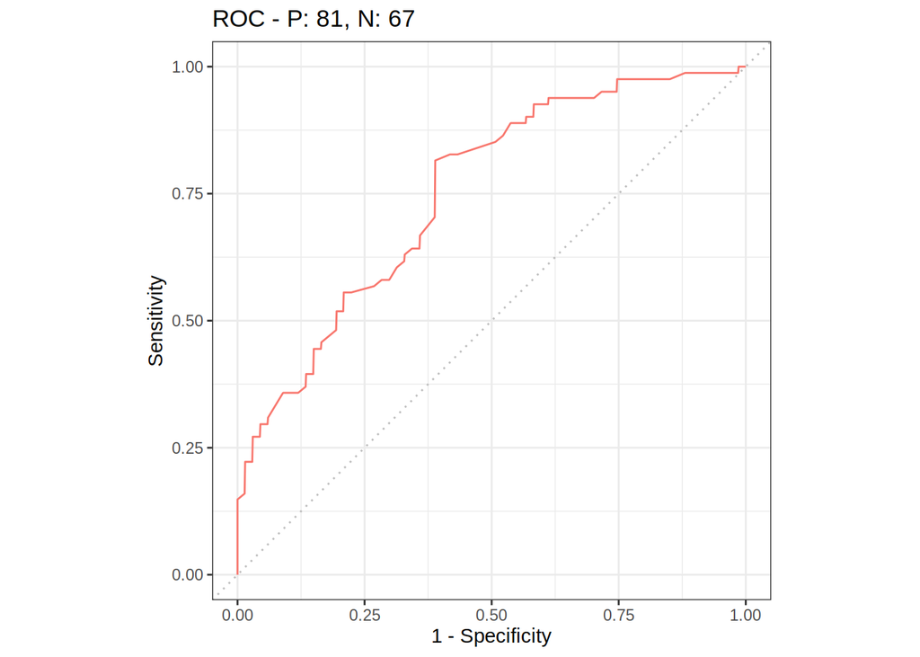

```r
autoplot(prediction, type='roc')
```

```r
prediction$score(msr('classif.auc'))
```

```
## classif.auc
##    0.751428
```

### Zastąpienie braków średnią

```r
# zastapienie brakow zmiennej PMCno najczesciej wystepujaca wartoscia, wyznaczona na zbiorze treningowym
new_data <- mutate(data, PMCno=ifelse(is.na(PMCno), sort(table(data$PMCno), decreasing=TRUE)[1], PMCno))

# zastapienie brakow pozostlaych zmiennych srednia, wyznaczona na zbiorze treningowym
variables <- unlist(lapply(new_data, function(x) any(is.na(x))))
variables <- names(variables)[variables]
for(variable in variables) {
  new_data[[variable]] <- ifelse(is.na(new_data[[variable]]), mean(new_data[train_set, variable], na.rm=T), new_data[[variable]])
}

# przygotowanie obiektow
resampling <- rsmp("cv", folds = 5)
encoder <- po('encode', method='one-hot', affect_columns=selector_type('factor'))
learner <- lrn('classif.glmnet', predict_type = 'prob')
glearner <- GraphLearner$new(encoder %>>% learner)

# kroswalidacja na zbiorze treningowym
task_1 <- TaskClassif$new(id='eucalyptus', backend=new_data[train_set, ], target='Utility', positive='1')
rr <- resample(task_1, glearner, resampling, store_models = TRUE)
```

```
## INFO  [17:47:21.412] Applying learner 'encode.classif.glmnet' on task 'eucalyptus' (iter 1/5)
## INFO  [17:47:21.817] Applying learner 'encode.classif.glmnet' on task 'eucalyptus' (iter 2/5)
## INFO  [17:47:22.234] Applying learner 'encode.classif.glmnet' on task 'eucalyptus' (iter 3/5)
## INFO  [17:47:22.657] Applying learner 'encode.classif.glmnet' on task 'eucalyptus' (iter 4/5)
## INFO  [17:47:23.113] Applying learner 'encode.classif.glmnet' on task 'eucalyptus' (iter 5/5)
```

```r
rr$score(msr('classif.acc'))[, c('iteration', 'classif.acc')]
```

```
##    iteration classif.acc
## 1:         1   0.8813559
## 2:         2   0.8728814
## 3:         3   0.8728814
## 4:         4   0.8888889
## 5:         5   0.8974359
```

```r
rr$score(msr('classif.ce'))[, c('iteration', 'classif.ce')]
```

```
##    iteration classif.ce
## 1:         1  0.1186441
## 2:         2  0.1271186
## 3:         3  0.1271186
## 4:         4  0.1111111
## 5:         5  0.1025641
```

```r
rr$score(msr('classif.precision'))[, c('iteration', 'classif.precision')]
```

```
##    iteration classif.precision
## 1:         1         0.9574468
## 2:         2         0.8000000
## 3:         3         0.8947368
## 4:         4         0.8400000
## 5:         5         0.8490566
```

```r
rr$score(msr('classif.recall'))[, c('iteration', 'classif.recall')]
```

```
##    iteration classif.recall
## 1:         1      0.7894737
## 2:         2      0.8205128
## 3:         3      0.8500000
## 4:         4      0.8936170
## 5:         5      0.9183673
```

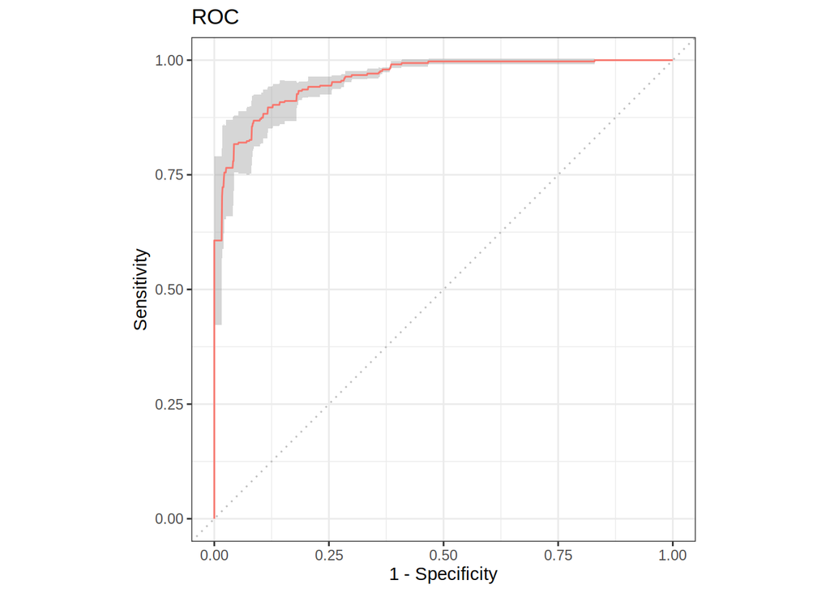

```r
autoplot(rr, type='roc')
```

```r
# uczenie na calym zbiorze treningowym
task_2 <- TaskClassif$new(id='eucalyptus', backend=new_data, target='Utility', positive='1')
glearner$train(task_2, row_ids=train_set)

# ocena na zbiorze testowym
prediction <- glearner$predict(task_2, row_ids=test_set)

prediction$score(msr('classif.acc'))
```

```
## classif.acc
##   0.8986486
```

```r
prediction$score(msr('classif.ce'))
```

```
## classif.ce
##  0.1013514
```

```r
prediction$score(msr('classif.precision'))
```

```
## classif.precision
##           0.90625
```

```r
prediction$score(msr('classif.recall'))
```

```
## classif.recall
##      0.8656716
```

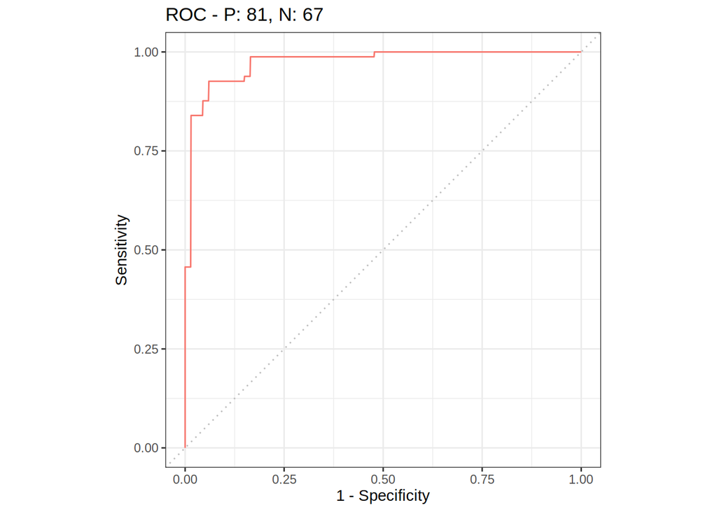

```r
autoplot(prediction, type='roc')
```

```r
prediction$score(msr('classif.auc'))
```

```
## classif.auc
##   0.9738345
```

### Zastąpienie braków medianą

```r
# zastapienie brakow zmiennej PMCno najczesciej wystepujaca wartoscia, wyznaczona na zbiorze treningowym
new_data <- mutate(data, PMCno=ifelse(is.na(PMCno), sort(table(data$PMCno), decreasing=TRUE)[1], PMCno))

# zastapienie brakow pozostlaych zmiennych mediaba, wyznaczona na zbiorze treningowym
variables <- unlist(lapply(new_data, function(x) any(is.na(x))))
variables <- names(variables)[variables]
for(variable in variables) {
  new_data[[variable]] <- ifelse(is.na(new_data[[variable]]), median(new_data[train_set, variable], na.rm=T), new_data[[variable]])
}

# przygotowanie obiektow
resampling <- rsmp("cv", folds = 5)
encoder <- po('encode', method='one-hot', affect_columns=selector_type('factor'))
learner <- lrn('classif.glmnet', predict_type = 'prob')
glearner <- GraphLearner$new(encoder %>>% learner)

# kroswalidacja na zbiorze treningowym
task_1 <- TaskClassif$new(id='eucalyptus', backend=new_data[train_set, ], target='Utility', positive='1')
rr <- resample(task_1, glearner, resampling, store_models = TRUE)
```

```
## INFO  [17:47:24.732] Applying learner 'encode.classif.glmnet' on task 'eucalyptus' (iter 1/5)
## INFO  [17:47:25.138] Applying learner 'encode.classif.glmnet' on task 'eucalyptus' (iter 2/5)
## INFO  [17:47:25.517] Applying learner 'encode.classif.glmnet' on task 'eucalyptus' (iter 3/5)
## INFO  [17:47:25.929] Applying learner 'encode.classif.glmnet' on task 'eucalyptus' (iter 4/5)
## INFO  [17:47:26.341] Applying learner 'encode.classif.glmnet' on task 'eucalyptus' (iter 5/5)
```

```r
rr$score(msr('classif.acc'))[, c('iteration', 'classif.acc')]
```

```
##    iteration classif.acc
## 1:         1   0.8728814
## 2:         2   0.8559322
## 3:         3   0.8813559
## 4:         4   0.8888889
## 5:         5   0.8974359
```

```r
rr$score(msr('classif.ce'))[, c('iteration', 'classif.ce')]
```

```
##    iteration classif.ce
## 1:         1  0.1271186
## 2:         2  0.1440678
## 3:         3  0.1186441
## 4:         4  0.1111111
## 5:         5  0.1025641
```

```r
rr$score(msr('classif.precision'))[, c('iteration', 'classif.precision')]
```

```
##    iteration classif.precision
## 1:         1         0.9423077
## 2:         2         0.7708333
## 3:         3         0.9285714
## 4:         4         0.8196721
## 5:         5         0.9047619
```

```r
rr$score(msr('classif.recall'))[, c('iteration', 'classif.recall')]
```

```
##    iteration classif.recall
## 1:         1      0.8032787
## 2:         2      0.8604651
## 3:         3      0.7800000
## 4:         4      0.9615385
## 5:         5      0.8260870
```

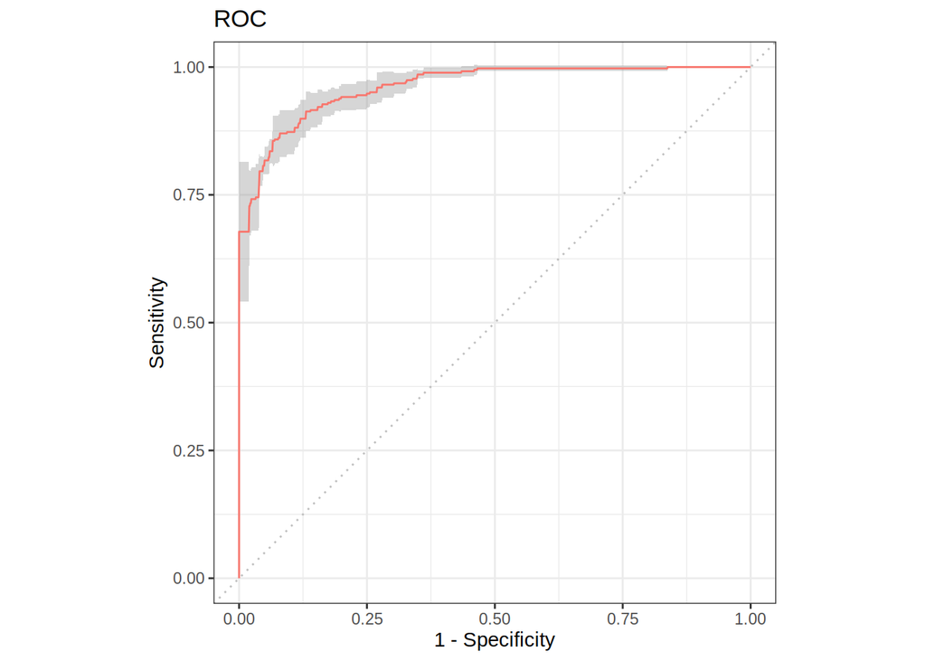

```r
autoplot(rr, type='roc')
```

```r
# uczenie na calym zbiorze treningowym
task_2 <- TaskClassif$new(id='eucalyptus', backend=new_data, target='Utility', positive='1')
glearner$train(task_2, row_ids=train_set)

# ocena na zbiorze testowym
prediction <- glearner$predict(task_2, row_ids=test_set)

prediction$score(msr('classif.acc'))
```

```
## classif.acc
##   0.8986486
```

```r
prediction$score(msr('classif.ce'))
```

```
## classif.ce
##  0.1013514
```

```r
prediction$score(msr('classif.precision'))
```

```
## classif.precision
##           0.90625
```

```r
prediction$score(msr('classif.recall'))
```

```
## classif.recall
##      0.8656716
```

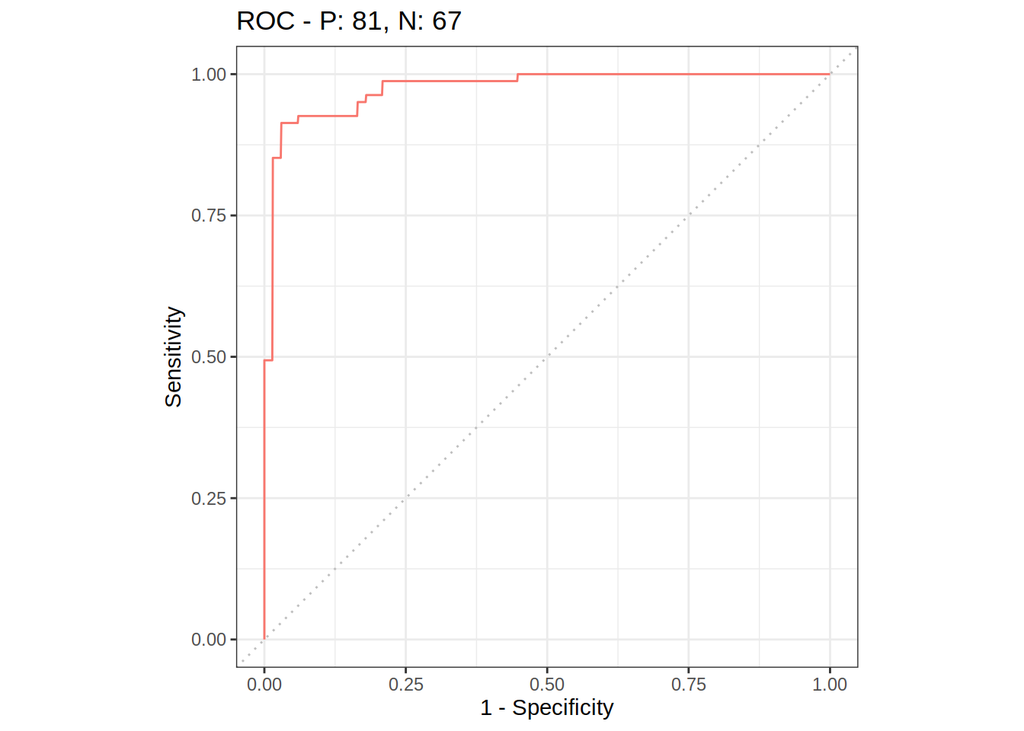

```r
autoplot(prediction, type='roc')
```

```r
prediction$score(msr('classif.auc'))
```

```
## classif.auc
##   0.9751244
```

#### Komentarz

**Kroswalidacja na zbiorze treningowym:**

W przypadku kroswaliwdacji na zbiorze treningowym różnice w wynikach pomiędzy iteracjami nie były podejrzanie duże dla żadnej z metod imputacji. Największe ze wspomnianych różnic zaobserwowano przy usuwaniu kolumn.

**Wyniki na zbiorze testowym:**

Oznaczmy metody imputacji następująco:

- RR - usunięcie wierszy z brakami danych
- CR - usunięcie kolumn z brakami danych
- MEDIAN - zastąpeienie braków danych medianą
- MEAN - zastąpeienie braków danych średnią